# Loan_Eligible (1)

### Análise individual dos melhores tratamentos

## Modelo 1 - Tomke Link - Label Encoder - Normalização Gausseana - Standard Scaler

```python
balance = 2
skf = StratifiedKFold(n_splits=30, shuffle=True, random_state=0) # Separação dos dados
c = 30
treino_tratado , test_tratado, texto = tratamento(0,1,1)
resultados = []
for train_index, test_index in skf.split(treino_tratado.drop('Loan_Status',axis=1), treino_tratado['Loan_Status']):
  print(f'Rodagem de número: {c}/30')
  c -=1
  y_tratado = treino_tratado['Loan_Status']

  X_tr = treino_tratado.iloc[train_index, :].drop('Loan_Status', axis=1)
  X_te = treino_tratado.iloc[test_index, :].drop('Loan_Status', axis=1)
  y_tr = y_tratado.iloc[train_index]
  y_te = y_tratado.iloc[test_index]

  X_tr, y_tr = balanceamento(X_tr, y_tr, balance)
  resultados = modelos_ml(X_tr, X_te, y_tr, y_te, resultados)


grafico = pd.DataFrame(resultados, columns=['Modelo','F1','ROC']).sort_values(by='F1',ascending=False).reset_index(drop=True).dropna()
```

```
Rodagem de número: 30/30
Rodagem de número: 29/30
Rodagem de número: 28/30
Rodagem de número: 27/30
Rodagem de número: 26/30
Rodagem de número: 25/30
Rodagem de número: 24/30
Rodagem de número: 23/30
Rodagem de número: 22/30
Rodagem de número: 21/30
Rodagem de número: 20/30
Rodagem de número: 19/30
Rodagem de número: 18/30
Rodagem de número: 17/30
Rodagem de número: 16/30
Rodagem de número: 15/30
Rodagem de número: 14/30
Rodagem de número: 13/30
Rodagem de número: 12/30
Rodagem de número: 11/30
Rodagem de número: 10/30
Rodagem de número: 9/30
Rodagem de número: 8/30
Rodagem de número: 7/30
Rodagem de número: 6/30
Rodagem de número: 5/30
Rodagem de número: 4/30
Rodagem de número: 3/30
Rodagem de número: 2/30
Rodagem de número: 1/30
```

```python
res_dict = {'modelo_1':grafico }
```

## Modelo 2 - Tomke Link - Frequency Encoder - Normalização Gausseana - Sem Padronização

```python
balance = 2
skf = StratifiedKFold(n_splits=30, shuffle=True, random_state=0) # Separação dos dados
c = 30
treino_tratado , test_tratado, texto = tratamento(2,0,1)
resultados = []
for train_index, test_index in skf.split(treino_tratado.drop('Loan_Status',axis=1), treino_tratado['Loan_Status']):
  print(f'Rodagem de número: {c}/30')
  c -=1
  y_tratado = treino_tratado['Loan_Status']

  X_tr = treino_tratado.iloc[train_index, :].drop('Loan_Status', axis=1)
  X_te = treino_tratado.iloc[test_index, :].drop('Loan_Status', axis=1)
  y_tr = y_tratado.iloc[train_index]
  y_te = y_tratado.iloc[test_index]

  X_tr, y_tr = balanceamento(X_tr, y_tr, balance)
  resultados = modelos_ml(X_tr, X_te, y_tr, y_te, resultados)


grafico = pd.DataFrame(resultados, columns=['Modelo','F1','ROC']).sort_values(by='F1',ascending=False).reset_index(drop=True).dropna()
```

```
Rodagem de número: 30/30
Rodagem de número: 29/30
Rodagem de número: 28/30
Rodagem de número: 27/30
Rodagem de número: 26/30
Rodagem de número: 25/30
Rodagem de número: 24/30
Rodagem de número: 23/30
Rodagem de número: 22/30
Rodagem de número: 21/30
Rodagem de número: 20/30
Rodagem de número: 19/30
Rodagem de número: 18/30
Rodagem de número: 17/30
Rodagem de número: 16/30
Rodagem de número: 15/30
Rodagem de número: 14/30
Rodagem de número: 13/30
Rodagem de número: 12/30
Rodagem de número: 11/30
Rodagem de número: 10/30
Rodagem de número: 9/30
Rodagem de número: 8/30
Rodagem de número: 7/30
Rodagem de número: 6/30
Rodagem de número: 5/30
Rodagem de número: 4/30
Rodagem de número: 3/30
Rodagem de número: 2/30
Rodagem de número: 1/30
```

```python
res_dict.update({'modelo_2':grafico})
```

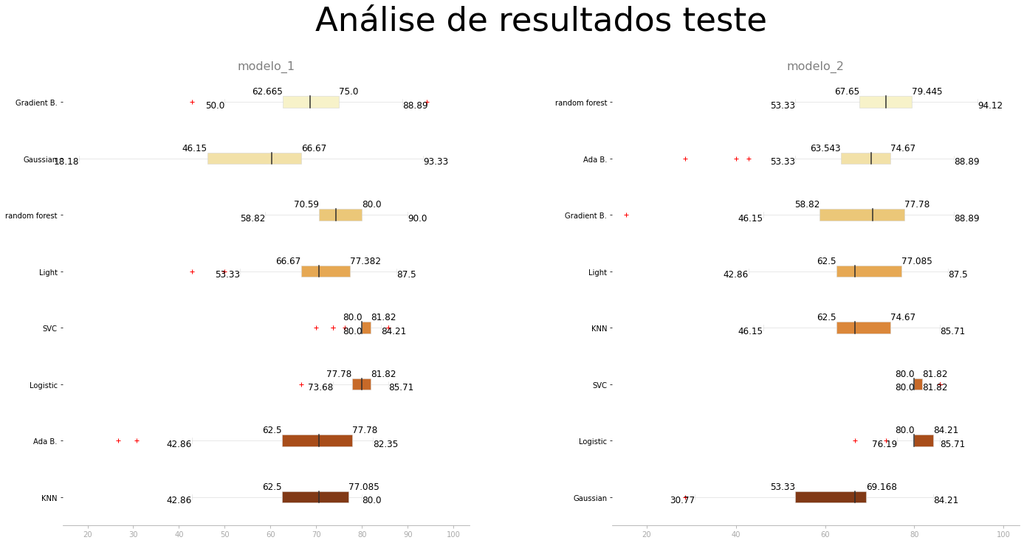

```python
analise_grafica(res_dict,'teste')
```

## Análise de resultados

- A escolha do gráfico de caixa (quartis) é muito importante para avaliarmos um contexto de escolha do modelo mais adequado.
- Exemplo: Se a finalidade do resultado for manter algo bem consistente e acima de 80% de acerto, a escolha do SVC do modelo 2, visto que o menor valor foi 80% sem outliers, o único outliers foi um valor acima da máxima (algo positivo)
- Percebe-se que os modelos baseados em árvore de decisão apresentaram uma amplitude total muito elevada, com resultados muito bons mas também muito ruim. Esses modelos funcionam muito bem quando se aplica um hiper parâmetro, que vai escolher uma combinação de resultados melhor para cada tipo de dataset, mas como o objetivo aqui é fazer uma análise dos dados e do comportamento dos modelos de previsão desses dados, esse tema talvez será abordado futuramente.
- Sendo assim, o melhor resultado foi:
  - Balanceamento : **Tomek Link**
  - Encoder : **Frequency Encoder**
  - Normalização : **Normalização Gausseana**
  - Padronização : **Sem padronização**
  - Técnica de machine learning : **SVC**